# Weed-Competitive Wheat

Does weed species matter?

Cathrine H Ingvordsen

Agriculture and Food

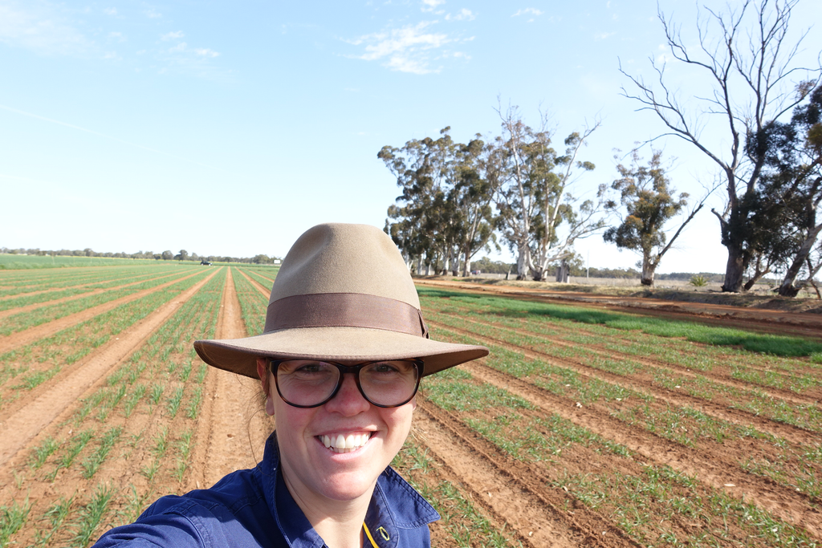

# Introduction

Hi, welcome to my Data School Final Project! I joined CSIRO in 2015 leaving Denmark for this great opportunity to work on agriculture in a country with tight link between growers and scientists.

Before joining Data School my R experience was adopting colleagues’ scripts and running them on my own data - once combating the challenge of how to load data. Experiencing more of the power R has on offer during Data School, I’m now determined to find the time to compose my own R scripts and free myself from excel and untraceable errors.

# My Project

In our project team we exploit early vigour to breed weed-competitive wheat and proof of concept test the competitiveness caused by high-vigour. Our data comes from field trials and are predominantly phenotype data in the form of scores (1-5), weights or counts. We typically run our trials in several environments, which can be different sites, irrigation regimes or years. We also measure co-factors such as length of plots and weather data.

## Does weed species matter?

Table 1: Weed-surrogates

| Weed surrogate | Abbreviation | Variety | mimick |
| --- | --- | --- | --- |
| Winter Ryegrass | Wr | Winterstar | Annual ryegrass |
| Canola | Ca | InVigour T 4510 | Wild radish |
| Tall oat | Bo | Bannister | Wild oat |
| Short oat | Mo | Mitika | Wild oat |
| Tall barley | Fb | Fathom | Barley, Barnyard grass |
| Short barley | Hb | Hindmarsh | Barley, Barnyard grass |

## Preliminary results

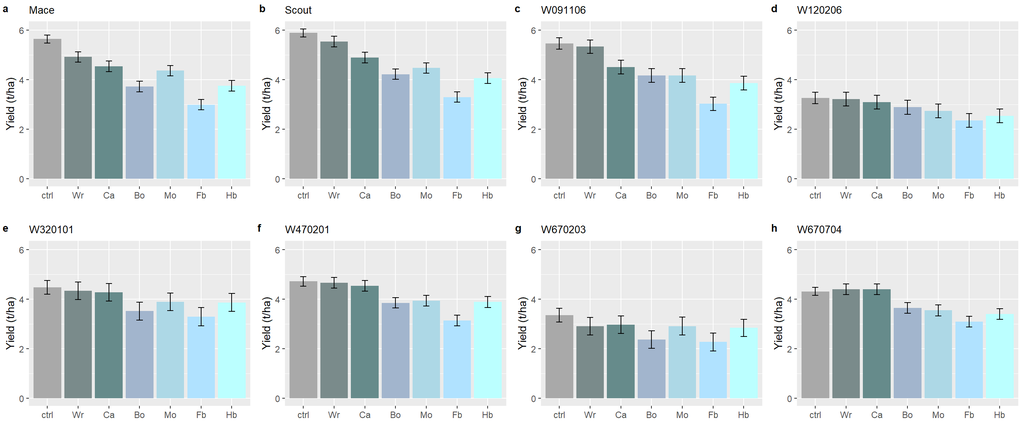

Figure 1: Wheat grain yield of Australian commercial varieties Mace and Scout and developed high-vigour lines W091106, W120206, W320101, W470201, W670203, W670704 grown in Condobolin without competition (ctrl) or in competition with winter ryegrass (Wr), canola (Ca), tall oat (Bo; Bannister oat), short oat (Mo; Mitika oat), tall barley (Fb; Fathom barley) and short barley (Hb; Hindmarsh barley).

# My Digital Toolbox

I’ve filled my digital toolbox with numerous functions of tidyverse. To not manipulate my field scorings made in excel I’ll use full_join to combine the sheets many, many times. I’ll use functions from the regular expressions to secure consistency in naming, scorings, measurements and comments. Finally, when getting to the data analysis ggplot will be my go-to for initial data exploration and visualisation for final publications. Regarding ggplot I suspect I’ll get across more than what we’ve learned in Data School.

# My time went …

My time went primarily with ggplot for this final project, making already analysed data presentable. Going back and forth from script to final presentation considering e.g. font size was more time consuming than I expected.

# Next steps

Next step is prioritising time for R and keep doing that. In the future I’d get really excited by a database to store field data measurements and photos designed by field scientists. Such data base would free me from my own folder system, which in busy times gets chaotic, and further free up space on my computer.

# My Data School Experience

My Data School has been brilliant. Huge Thanks to Team Kristian, Stephen and Karensa!

I’m now more confident that the time invested in R is paying off and tasks possible with the support of the Data School network. Moving into the habit of using R systemically and frequently has already begun with establishing my freshly sown trials with a R project for each trial. The personal impact will initially be investment of time and later when I can reuse my own(!) R scripts save me time.